# Parical 2 Estadistica en Ciencia de los Datos

**Por:**

- JAVIER LEOMAR MATAMOROS VILLEGAS
- ALVARO ANDRES CASTRO PEREZ
- VLADIMIR ARREDONDO CORREA
- JUAN PABLO GAVIRIA SALAZAR

```python
# Librerias
import pandas as pd
import numpy as np
from sklearn.decomposition import PCA
from sklearn_extra.cluster import KMedoids
import networkx as nx
import string
import pygraphviz
from sklearn import manifold
import matplotlib.pyplot as plt
from sklearn.linear_model import LinearRegression
from IPython.display import Image
```

## Punto 1

[30 puntos] Considere los datos que se encuentran en el archivo Parcial2.txt. La variable respuesta es ’lpsa’. Y las variables explicativas son [’lcavol’, ’lweight’, ’age’, ’lbph’,’svi’, ’lcp’, ’gleason’, ’pgg45’]

- (5 puntos) Considerando solamente la matriz con las varibles explicativas: calcule la varianza total de los datos. Usted debe devolver el valor de la varianza total de los datos. Calcule las componentes principales y determine la varianza explicada por cada componente.
- (10 puntos) Esprese los datos en el plano de las dos primeras componentes principales.
- (10 puntos) Calcule los parámetros de la regresión de Y sobre las dos primeras componentes principales.
- (5 puntos) Use el modelo de predicción Base error rate con los datos originales (sin hacer componentes principales) y compare el R2con el obtenido en el punto anterior. Use la referencia: https : //scikit − learn.org/stable/modules/modelevaluation.html.

```python
data = pd.read_csv('parcial2.txt')
data
```

|  | id | lcavol | lweight | age | lbph | svi | lcp | gleason | pgg45 | lpsa | train |
| --- | --- | --- | --- | --- | --- | --- | --- | --- | --- | --- | --- |
| 0 | 1 | -0.579818 | 2.769459 | 50 | -1.386294 | 0 | -1.386294 | 6 | 0 | -0.430783 | T |
| 1 | 2 | -0.994252 | 3.319626 | 58 | -1.386294 | 0 | -1.386294 | 6 | 0 | -0.162519 | T |
| 2 | 3 | -0.510826 | 2.691243 | 74 | -1.386294 | 0 | -1.386294 | 7 | 20 | -0.162519 | T |
| 3 | 4 | -1.203973 | 3.282789 | 58 | -1.386294 | 0 | -1.386294 | 6 | 0 | -0.162519 | T |
| 4 | 5 | 0.751416 | 3.432373 | 62 | -1.386294 | 0 | -1.386294 | 6 | 0 | 0.371564 | T |
| ... | ... | ... | ... | ... | ... | ... | ... | ... | ... | ... | ... |
| 92 | 93 | 2.830268 | 3.876396 | 68 | -1.386294 | 1 | 1.321756 | 7 | 60 | 4.385147 | T |
| 93 | 94 | 3.821004 | 3.896909 | 44 | -1.386294 | 1 | 2.169054 | 7 | 40 | 4.684443 | T |
| 94 | 95 | 2.907447 | 3.396185 | 52 | -1.386294 | 1 | 2.463853 | 7 | 10 | 5.143124 | F |
| 95 | 96 | 2.882564 | 3.773910 | 68 | 1.558145 | 1 | 1.558145 | 7 | 80 | 5.477509 | T |
| 96 | 97 | 3.471966 | 3.974998 | 68 | 0.438255 | 1 | 2.904165 | 7 | 20 | 5.582932 | F |

97 rows × 11 columns

```python
xs = data.drop(columns=['id','lpsa','train'])
```

### Varianza total y componentes principales

```python
# Varianza total
covarianza = xs.cov()
varianza = np.trace(covarianza)
print('Varianza total '+str(round(varianza,3)))
```

```
Varianza total 857.223
```

```python
# Componentes principales
pca = PCA(len(xs.columns))
pca.fit(xs)
```

```
PCA(copy=True, iterated_power='auto', n_components=8, random_state=None,
    svd_solver='auto', tol=0.0, whiten=False)
```

```python
print('Componentes principales:')
print(pca.components_)
```

```
Componentes principales:
[[ 1.81960864e-02  1.72942225e-03  7.75919621e-02  4.37097167e-03
   6.70192766e-03  3.12030856e-02  1.92178481e-02  9.96111650e-01]
 [-1.67669186e-02 -2.00518260e-02 -9.93964180e-01 -7.16174200e-02
   1.13989867e-03  1.20715706e-02 -4.96411933e-03  7.77900037e-02]
 [ 4.85357703e-01 -2.84994785e-02  4.64550477e-02 -6.94182154e-01
   1.32043988e-01  5.09944607e-01  3.69132993e-02 -2.69636436e-02]
 [-4.74848266e-01 -1.38117646e-01  5.75995322e-02 -7.05469647e-01
  -8.68332749e-02 -4.94971233e-01 -3.61937213e-02  2.43102431e-02]
 [ 7.15299225e-01  6.06260442e-02 -2.06481086e-02 -1.34650646e-02
  -8.86729563e-02 -6.79271051e-01  1.21356201e-01  8.02913565e-03]
 [-8.98907428e-02 -2.40639377e-01 -8.50310206e-04  2.47689788e-02
  -1.37051397e-01  7.14330829e-02  9.53519408e-01 -1.76942772e-02]
 [-1.29966572e-01  9.47191043e-01 -1.04886183e-02 -1.11038856e-01
   1.10046527e-01 -2.00844712e-02  2.46934166e-01 -2.84144835e-03]
 [-4.13540847e-02 -1.44749891e-01 -1.35675851e-03  4.63801424e-02
   9.67585622e-01 -1.64089577e-01  1.09683106e-01 -2.57711828e-03]]
```

```python
print('Varianza explicada por cada componente:')
print(pca.explained_variance_)
```

```
Varianza explicada por cada componente:
[8.01375038e+02 5.12111108e+01 1.97090426e+00 1.75854773e+00
 4.78083003e-01 2.24163498e-01 1.21394222e-01 8.35994759e-02]
```

```python
print('Porcentaje (%) de varianza explicada:')
print(pca.explained_variance_ratio_.round(3)*100)
```

```
Porcentaje (%) de varianza explicada:
[93.5  6.   0.2  0.2  0.1  0.   0.   0. ]
```

### Plano de las 2 primeras componentes principales

```python
proy = pca.transform(xs)[:,0:2]
plt.plot(proy[:,0],proy[:,1], 'o')
```

[figure not shown]

### Regresión de Y sobre los dos primeros componentes principales

```python
model= LinearRegression()
reg = model.fit(proy, data['lpsa'])
```

```python
print('R squared del modelo')
print(reg.score(proy, data['lpsa']))
print('Coeficientes:')
print(reg.coef_)
print('Intercepto:')
print(reg.intercept_)
```

```
R squared del modelo
0.18249733121056544
Coeficientes:
[ 0.01730037 -0.00805086]
Intercepto:
2.4783868783505154
```

### Regresión sobre la data original

```python
reg = model.fit(xs, data['lpsa'])
```

```python
print('R squared del modelo')
print(reg.score(xs, data['lpsa']))
print('Coeficientes:')
print(reg.coef_)
print('Intercepto:')
print(reg.intercept_)
```

```
R squared del modelo
0.6633895654989245
Coeficientes:
[ 0.56434128  0.62201979 -0.02124819  0.09671252  0.7616734  -0.10605094
  0.04922793  0.00445751]
Intercepto:
0.18156084546895634
```

### Conclusión

La matriz explicativa total, representa el 66% de la variable y, mientras que los 2 mayores componentes principales solo representan un 18% de la variable y

## Punto 2

[10 puntos] Considere los siguientes datos en parcial22.txt

Ejecute el algoritmo de k-medias y compare los resultados con el algoritmo de kmeans. Se tiene alguna conclusión natural?

Redacte sus conclusiones.

Debido a que solo se da la matriz de distancias, no es posible implementar kmeans, ya que a falta de información no se puede sacar los promedios

```python
data = pd.read_csv('parcial2_2.txt', delimiter=' ')
data
```

|  | Country | BEL | BRA | CHI | CUB | EGY | FRA | IND | ISR | USA | USS | YUG | ZAI |
| --- | --- | --- | --- | --- | --- | --- | --- | --- | --- | --- | --- | --- | --- |
| 0 | BEL | 0.00 | 5.58 | 7.00 | 7.08 | 4.83 | 2.17 | 6.42 | 3.42 | 2.50 | 6.08 | 5.25 | 4.75 |
| 1 | BRA | 5.58 | 0.00 | 6.50 | 7.00 | 5.08 | 5.75 | 5.00 | 5.50 | 4.92 | 6.67 | 6.83 | 3.00 |
| 2 | CHI | 7.00 | 6.50 | 0.00 | 3.83 | 8.17 | 6.67 | 5.58 | 6.42 | 6.25 | 4.25 | 4.50 | 6.08 |
| 3 | CUB | 7.08 | 7.00 | 3.83 | 0.00 | 5.83 | 6.92 | 6.00 | 6.42 | 7.33 | 2.67 | 3.75 | 6.67 |
| 4 | EGY | 4.83 | 5.08 | 8.17 | 5.83 | 0.00 | 4.92 | 4.67 | 5.00 | 4.50 | 6.00 | 5.75 | 5.00 |
| 5 | FRA | 2.17 | 5.75 | 6.67 | 6.92 | 4.92 | 0.00 | 6.42 | 3.92 | 2.25 | 6.17 | 5.42 | 5.58 |
| 6 | IND | 6.42 | 5.00 | 5.58 | 6.00 | 4.67 | 6.42 | 0.00 | 6.17 | 6.33 | 6.17 | 6.08 | 4.83 |
| 7 | ISR | 3.42 | 5.50 | 6.42 | 6.42 | 5.00 | 3.92 | 6.17 | 0.00 | 2.75 | 6.92 | 5.83 | 6.17 |
| 8 | USA | 2.50 | 4.92 | 6.25 | 7.33 | 4.50 | 2.25 | 6.33 | 2.75 | 0.00 | 6.17 | 6.67 | 5.67 |
| 9 | USS | 6.08 | 6.67 | 4.25 | 2.67 | 6.00 | 6.17 | 6.17 | 6.92 | 6.17 | 0.00 | 3.67 | 6.50 |
| 10 | YUG | 5.25 | 6.83 | 4.50 | 3.75 | 5.75 | 5.42 | 6.08 | 5.83 | 6.67 | 3.67 | 0.00 | 6.92 |
| 11 | ZAI | 4.75 | 3.00 | 6.08 | 6.67 | 5.00 | 5.58 | 4.83 | 6.17 | 5.67 | 6.50 | 6.92 | 0.00 |

```python
x = data.drop(columns=['Country'])
kmedoides = KMedoids(n_clusters=2, random_state=0, metric='precomputed').fit(x)
```

```python
print('Clasificación:')
print(kmedoides.labels_)
```

```
Clasificación:
[1 1 0 0 1 1 0 1 1 0 0 1]
```

```python
adist = data.drop(columns=['Country']).values
amax = np.amax(adist)
adist /= amax

mds = manifold.MDS(n_components=2, dissimilarity="precomputed", random_state=6)
results = mds.fit(adist)

coords = results.embedding_

plt.subplots_adjust(bottom = 0.1)
plt.scatter(
    coords[:, 0], coords[:, 1], marker = 'o'
    )
plt.scatter(
    coords[kmedoides.labels_==1,0], coords[kmedoides.labels_==1,1], marker = 'o'
)
for label, x, y in zip(data.Country, coords[:, 0], coords[:, 1]):
    plt.annotate(
        label,
        xy = (x, y), xytext = (-20, 20),
        textcoords = 'offset points', ha = 'right', va = 'bottom',
        bbox = dict(boxstyle = 'round,pad=0.5', fc = 'yellow', alpha = 0.5),
        arrowprops = dict(arrowstyle = '->', connectionstyle = 'arc3,rad=0'))

plt.show()
```

[figure not shown]

## Punto 3

[10 puntos] Redacte la demostración del siguiente hecho:

La esperanza condicional E[Y |X] es la solución del problema de minimización

f(x) = arg mınc E((Y − c)^2 |X=x)

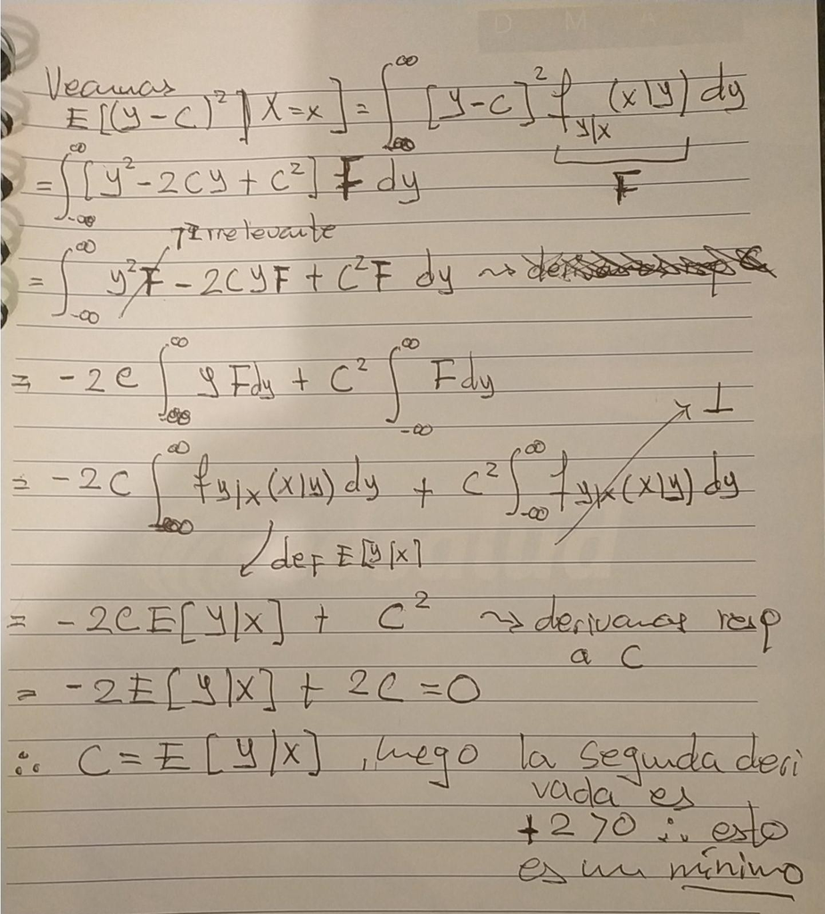

```python
Image(filename='demostracion1.png')
```

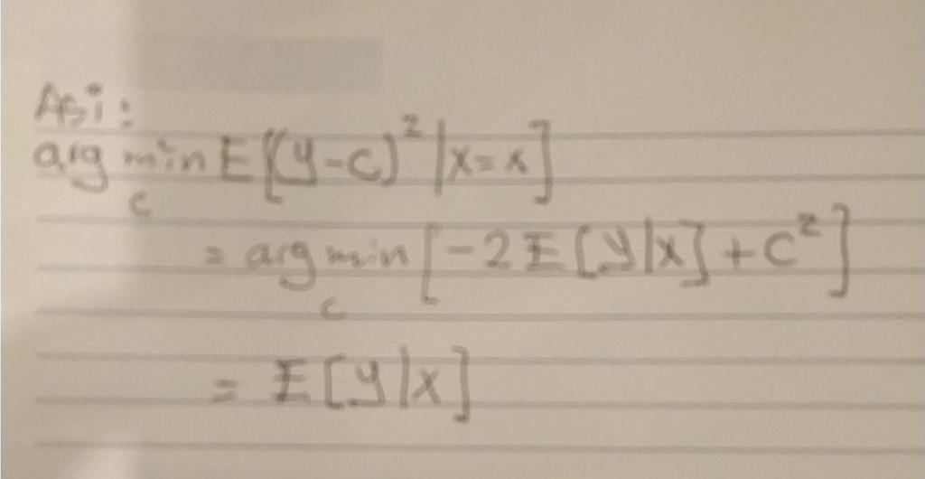

```python
Image(filename='demostracion2.png')
```